# Understanding the Electric Vehicle Landscape in the State of Washington

Title: Understanding the Electric Vehicle Landscape in the State of Washington

Author: Nicholas Rodriguez

Date: 10 April 2025

Modified By: Nicholas Rodriguez

Description: This program loads, cleans, and analyzes the Washington State Electric_Vehicle_Population_Data, generates visualizations and prepares supporting outputs.

Data Source: Washington State Department of Licensing

```python
##############################
# Import Libraries and Load the Data
##############################

import pandas as pd
import numpy as np
import seaborn as sns
import matplotlib.pyplot as plt

from sklearn.model_selection import train_test_split
from sklearn.preprocessing import OneHotEncoder, StandardScaler
from sklearn.compose import ColumnTransformer
from sklearn.pipeline import Pipeline
from sklearn.metrics import classification_report, mean_squared_error, r2_score
from sklearn.linear_model import LogisticRegression, LinearRegression
from sklearn.tree import DecisionTreeClassifier
from sklearn.ensemble import RandomForestClassifier
from sklearn.cluster import KMeans

df = pd.read_csv("Electric_Vehicle_Population_Data.csv")
```

```python
##############################
# Variable Selection for Analysis
##############################

cols = [
    "County", "City", "Model Year", "Make", "Model", "Electric Vehicle Type",
    "Clean Alternative Fuel Vehicle (CAFV) Eligibility", "Electric Range",
    "Base MSRP"
]

df = df[cols].copy()
```

```python
##############################
# Data Cleanup and Preparation
##############################

# Remove rows with missing values

df = df.dropna(subset=["Model Year", "Electric Range", "Base MSRP", "Electric Vehicle Type"])

# Standardize EV type labels

df["Electric Vehicle Type"] = df["Electric Vehicle Type"].replace({
    "Battery Electric Vehicle (BEV)": "BEV",
    "Plug-in Hybrid Electric Vehicle (PHEV)": "PHEV"
})

# Convert categorical variables to string

cat_cols = ["County", "City", "Make", "Model",
            "Electric Vehicle Type", "Clean Alternative Fuel Vehicle (CAFV) Eligibility"]

for col in cat_cols:
    df[col] = df[col].astype(str)

# Check

df.head()
```

|  | County | City | Model Year | Make | Model | Electric Vehicle Type | Clean Alternative Fuel Vehicle (CAFV) Eligibility | Electric Range | Base MSRP |
| --- | --- | --- | --- | --- | --- | --- | --- | --- | --- |
| 0 | Kitsap | Seabeck | 2021 | BMW | X5 | PHEV | Clean Alternative Fuel Vehicle Eligible | 30.0 | 0.0 |
| 1 | Kitsap | Poulsbo | 2018 | TESLA | MODEL 3 | BEV | Clean Alternative Fuel Vehicle Eligible | 215.0 | 0.0 |
| 2 | Snohomish | Bothell | 2016 | PORSCHE | PANAMERA | PHEV | Not eligible due to low battery range | 15.0 | 0.0 |
| 3 | Kitsap | Bremerton | 2018 | TESLA | MODEL 3 | BEV | Clean Alternative Fuel Vehicle Eligible | 215.0 | 0.0 |
| 4 | King | Redmond | 2019 | NISSAN | LEAF | BEV | Clean Alternative Fuel Vehicle Eligible | 150.0 | 0.0 |

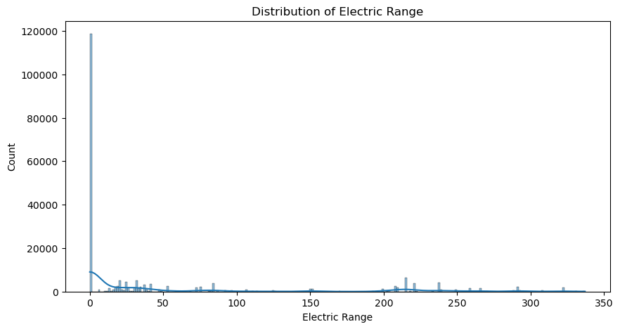

```python
##############################
# Exploratory Data Analysis
##############################

# Distribution of Electric Vehicle Range

plt.figure(figsize=(10,5))
sns.histplot(df["Electric Range"], kde=True)
plt.title("Distribution of Electric Range")
plt.show()
```

During analysis of this visualization, records were found to contain electric vehicles with a range of zero. Because no BEV or PHEV has an eletric only range of zero miles, these entries represent either missing data, data entry error, or data not relevant to this analysis. The presence of this data creates a clear distortion in the distribution of the electric range and artificially inflates the density seen at the lower end of the visualization. This results in obscuring the separation between PHEVs and BEVs. In an attempt to preserve accuracy and prevent erroneous values from influencing regression, classificaiton and clustering results, all zero-range records will be removed before modeling. This ensures that the analysis reflects realistic vehicle characteristics and maintains the conciseness and jargon free nature of this analysis.

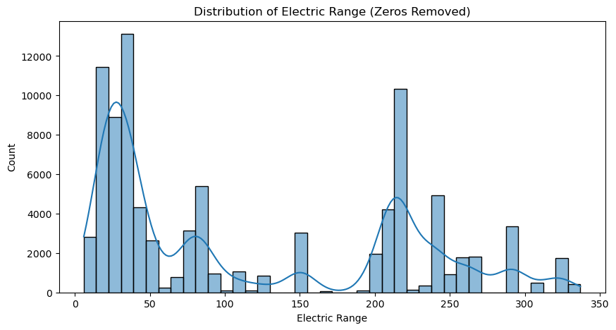

```python
# Distribution of Electric Vehicle Range (With Zeros Removed)

# Remove zero-range values

df_clean = df[df["Electric Range"] > 0].copy()

plt.figure(figsize=(10,5))
sns.histplot(df_clean["Electric Range"], kde=True, bins=40)
plt.title("Distribution of Electric Range (Zeros Removed)")
plt.show()
```

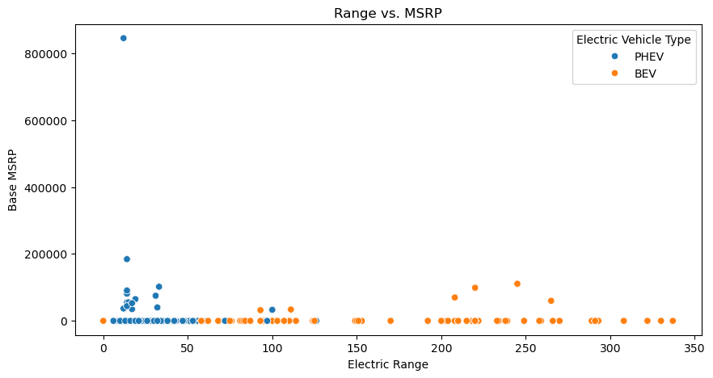

```python
# MSRP vs. Electric Range

plt.figure(figsize=(10,5))
sns.scatterplot(data=df, x="Electric Range", y="Base MSRP", hue="Electric Vehicle Type")
plt.title("Range vs. MSRP")
plt.show()
```

In the Range vs. MSRP scatterplot, the presence of vehicle record 68089 in the dataset, with an MSRP exceeding $800,000.00, is seen and creates a large vertical stretch in the plot. Because there are no other vehicles in the dataset that exceed $200,000.00, this single value compresses the rest of the points into a narrow band. The result is a visualization that hides meaningful structure, obscures BEV/PHEV separation, and makes the relationship between range and price appear much flatter and noisier than it truly is.

We can remove this value because it isn't representative of the EV market as a whole; it's a Porsche 918. This value harms the analysis by distorting the visualization, will lead to inflating regression error, disrupting scaling, and will reduce the interpretability of future models.

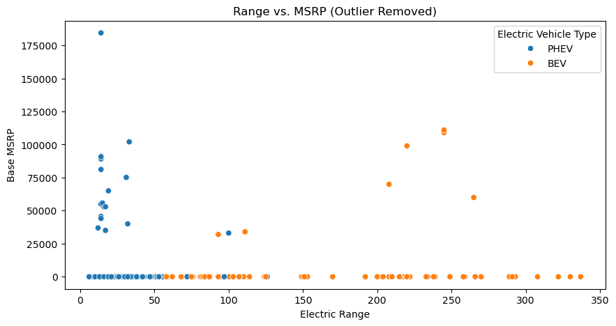

```python
# MSRP vs. Electric Range Outlier Removed

# Removal of outlier where MSRP = $845,000.00

df_clean = df[df["Base MSRP"] != 845000].copy()

# Remove zero range values

df_clean = df_clean[df_clean["Electric Range"] > 0].copy()

# Updated Range vs. MSRP Scatterplot

plt.figure(figsize=(10,5))
sns.scatterplot(data=df_clean, x="Electric Range", y="Base MSRP", hue="Electric Vehicle Type")
plt.title("Range vs. MSRP (Outlier Removed)")
plt.show()
```

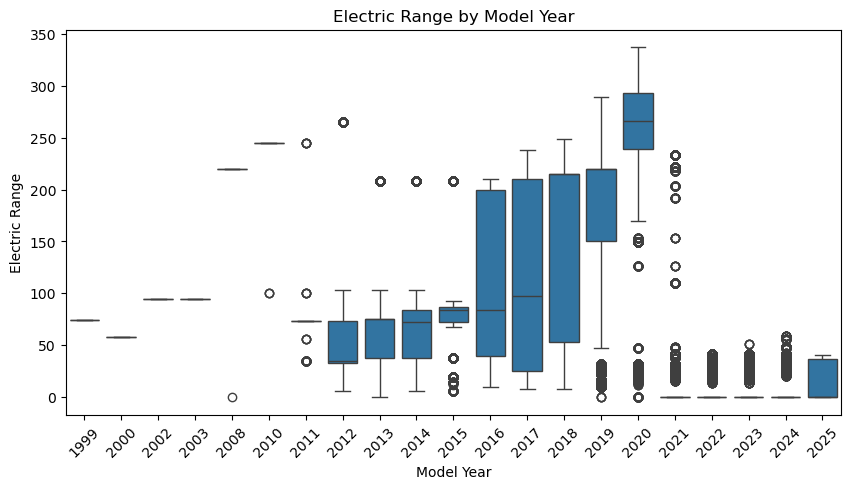

```python
# Model Year Trends

plt.figure(figsize=(10,5))
sns.boxplot(data=df, x="Model Year", y="Electric Range")
plt.title("Electric Range by Model Year")
plt.xticks(rotation=45)
plt.show()
```

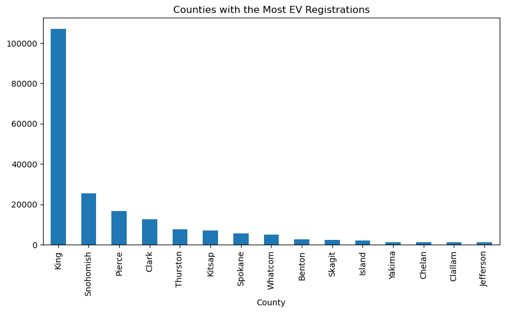

```python
# Geographic Patterns

plt.figure(figsize=(10,5))
df["County"].value_counts().head(15).plot(kind="bar")
plt.title("Counties with the Most EV Registrations")
plt.show()
```

```python
##############################
# Regression Modeling to Predict MSRP
##############################

# Define the feature matrix, X, and target vector, y, utilizing the cleaned dataset

X_reg = df_clean[["Model Year", "Electric Range", "Make", "Model", "County", "City"]]
y_reg = df_clean["Base MSRP"]

# Features to be one-hot encoded

numeric_features = ["Model Year", "Electric Range"]
categorical_features = ["Make", "Model", "County", "City"]

# Preprocessing pipeline with StandardScaler for numeric variables and one-hot encodes categorical features

preprocess_reg = ColumnTransformer(
    transformers=[
        ("num", StandardScaler(), numeric_features),
        ("cat", OneHotEncoder(handle_unknown="ignore"), categorical_features)
    ]
)

# Pipeline continues, preprocess data, fit linear regression model to ensure preprocessing is applied consistently

reg_model = Pipeline(steps=[
    ("preprocess", preprocess_reg),
    ("model", LinearRegression())
])

# 80 / 20 train/test split with random_state for reproducability

X_train, X_test, y_train, y_test = train_test_split(X_reg, y_reg, test_size=0.2, random_state=50)

reg_model.fit(X_train, y_train)
y_pred = reg_model.predict(X_test)

print("R² Score:", r2_score(y_test, y_pred))
print("RMSE:", np.sqrt(mean_squared_error(y_test, y_pred)))
```

```
R² Score: 0.3877747818356021
RMSE: 8694.625731910004
```

```python
##############################
# Classification Model to Predict Battery Electric Vehicle vs Plugin Hybrid Electric Vehicle
##############################

# Define feature matrix, X, and target vector, y, using the cleaned dataset

X_clf = df_clean[["Model Year", "Electric Range", "Make", "Model", "County", "City"]]
y_clf = df_clean["Electric Vehicle Type"]

# Preprocessing pipeline for classification, standardizes numeric features, and one-hot encodes categorical features

preprocess_clf = ColumnTransformer(
    transformers=[
        ("num", StandardScaler(), numeric_features),
        ("cat", OneHotEncoder(handle_unknown="ignore"), categorical_features)
    ]
)

# Classification pipeline, apply preprocessing, train a Random Forest classifier where n_estimators=200 for a stable
# ensemble and random_state for reproducability

clf_model = Pipeline(steps=[
    ("preprocess", preprocess_clf),
    ("model", RandomForestClassifier(n_estimators=200, random_state=50))
])

# 80 / 20 train/test split with random_state for reproducability

X_train_c, X_test_c, y_train_c, y_test_c = train_test_split(X_clf, y_clf, test_size=0.2, random_state=50)

clf_model.fit(X_train_c, y_train_c)
y_pred_c = clf_model.predict(X_test_c)

print(classification_report(y_test_c, y_pred_c))
```

```
              precision    recall  f1-score   support

         BEV       1.00      1.00      1.00      9300
        PHEV       1.00      1.00      1.00      9001

    accuracy                           1.00     18301
   macro avg       1.00      1.00      1.00     18301
weighted avg       1.00      1.00      1.00     18301
```

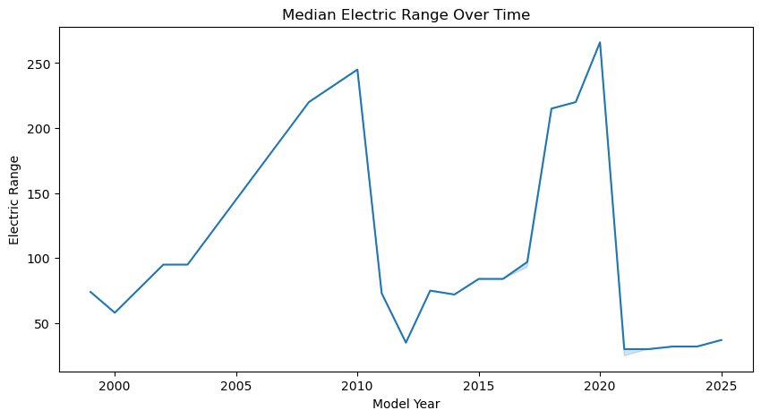

```python
##############################
# Trend Analysis of Range Over Time
##############################

plt.figure(figsize=(10,5))
sns.lineplot(data=df_clean, x="Model Year", y="Electric Range", estimator="median")
plt.title("Median Electric Range Over Time")
plt.show()
```

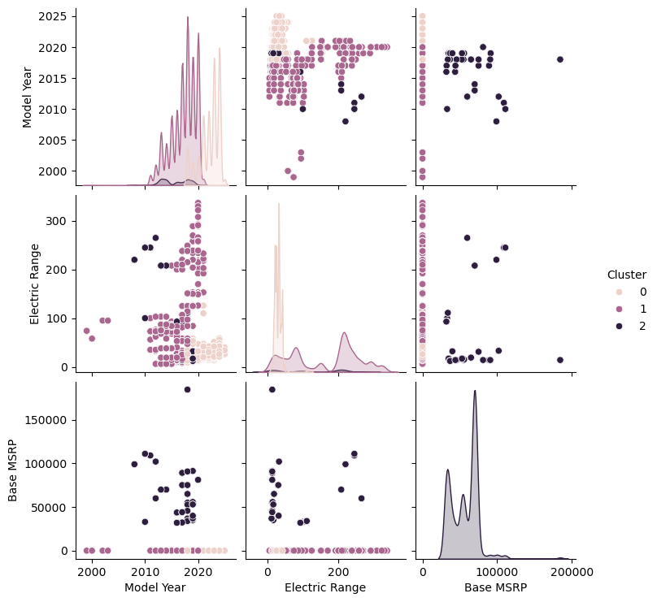

```python
##############################
# Clustering Vehicle Segmentation
##############################

# Select features for clustering from the df_clean dataset

cluster_df = df_clean[["Model Year", "Electric Range", "Base MSRP"]].dropna()

# Scale the features

scaler = StandardScaler()
scaled = scaler.fit_transform(cluster_df)

kmeans = KMeans(n_clusters=3, random_state=50)
cluster_df["Cluster"] = kmeans.fit_predict(scaled)

sns.pairplot(cluster_df, hue="Cluster")
plt.show()
```